# Project 2: Public Health & Epidemiology

# 3 Project future mortality

Your stakeholders have asked if you can quickly give them *any* idea of what to expect mortality to be across the counties for the remaining months of 2020. Now, even though you knew it would not be the most robust method for time series projection available (**a caveat!**), you immediately think to yourself, “Oh, I could do a regression.” So, you do.

## 3.1 Regression predictions of mortality in 2020

First, you need to do a little prep to the data to get you started. You need to calculate the monthly percent mortality and attach it to your mortality shapefile, `mortality_sf2`.

```r
## First, calculate monthly percent mortality in your dataframe:
mortality_sf2 <- mortality_sf2 %>%
  ## Group by County as well as Year
  group_by(COUNTY_NAM, Year, Month) %>%
  ## Summarize by calculating a monthly percent mortality
  ## Note that I have to divide by the mean of the N from the Census
  ## or I'd get an error
  summarize(monthlyPercMortality = sum(totalDeaths,
                                       na.rm = TRUE)/mean(totalN)*100) %>%
  ## Ungroup - necessary to remove the grouping for future use
  ungroup()
```

Now, fit the OLS linear regression.

```r
olsModel <- lm(monthlyPercMortality ~ COUNTY_NAM + Year + Month, data = mortality_sf2)
```

Next, make some new data (stored into `newdata`) so you can generate predictions for those new data.

```r
## Make the new data:
## Get the names of the counties; repeat four times for the 4 months
COUNTY_NAM <- rep(unique(mortality_sf2$COUNTY_NAM), 4)
## Make a set of months for each of the 58 counties for Sept, Oct, Nov, Dec
Month <- c(rep(9, 58),
            rep(10, 58),
            rep(11, 58),
            rep(12, 58))
Year <- rep(2020, length(Month))
## Put this into a new dataframe called "newdata"
newdata <- cbind.data.frame(COUNTY_NAM, Year, Month)
```

Now, generate the predictions using `newdata` and attach the predicted monthly percent mortality to `newdata`. This is necessary for plotting to occur! Make sure you **check out the dimensions of the `newdata`**. Since you are missing four months’ of data (September - December) in 2020, there she be a row for every county for every month missing.

```r
dim(newdata)
```

```
## [1] 232   3
```

```r
## Attach it to the dataframe and then call it the same name as the original Y
newdata$percMortality <- predict(olsModel, newdata = newdata)
## Also, add a flag so that you know it is predicted
newdata$isPredicted <- "1"
```

Finally, you are ready to make a temporary dataframe, which you will call `temp`, which will pull everything together - the original data and the predictions - so that you can add them to your line graphs from above. Although I could choose to add the predictions to your mortality shapefile instead, I am choosing not to in order to keep that more pristine. I don’t want to add predictions that I may not use in the future to my good dataframe!

```r
temp <- totalDeaths %>%   ## Start from totalDeaths for simplicity
  ## Join with census by County
  full_join(census, by = "County") %>%
  ## Group by Year and then Month to aggregate the counties
  group_by(Year, Month) %>%
  ## Calculate the percent mortality - it is a percent because multiply by 100
  summarise(percMortality = sum(totalDeaths, na.rm = TRUE) /
              sum(totalN, na.rm = TRUE)*100) %>%
  ## Keep only the columns you need
  select(Year, Month, percMortality) %>%
  ## Make an empty flag column filled with zeros to flag if the data are
  ## predicted
  mutate(isPredicted = "0")

## Clean up newdata a little: you need to aggregate across the counties by year
newdata <- newdata %>%
  ## Group by Year and then Month to aggregate the counties; add isPredicted
  ## in there too so that it makes it into the final dataset!
  group_by(Year, Month, isPredicted) %>%
  ## Remove what you don't need
  select(-COUNTY_NAM) %>%
  ## Calculate a mean percent mortality
  summarize(percMortality = mean(percMortality, na.rm = TRUE))

## Row bind newdata onto temp to give you a complete, ordered, dataset for plots!
temp <- rbind(temp, newdata)
```

Lastly, finish out the year of 2020 with predictions (shown in bubble points):

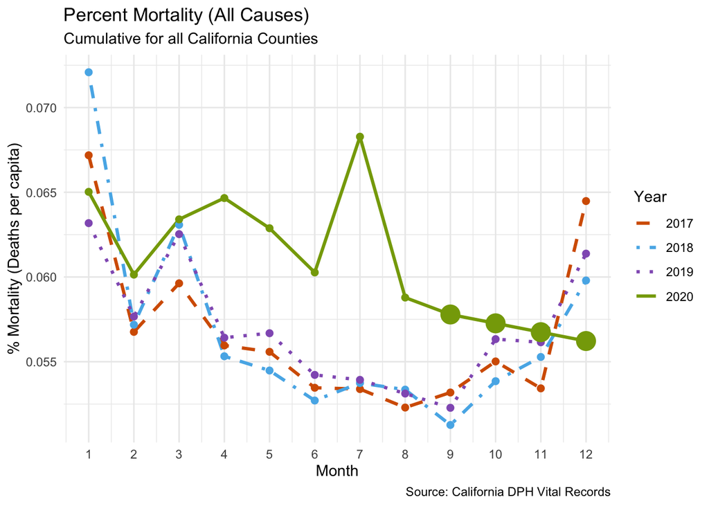

#### Question 16 [1 point]:

Do you think this regression prediction is robust? Why or why not? (**Hint**: Check your assumptions with `plot(olsModel)`!!)

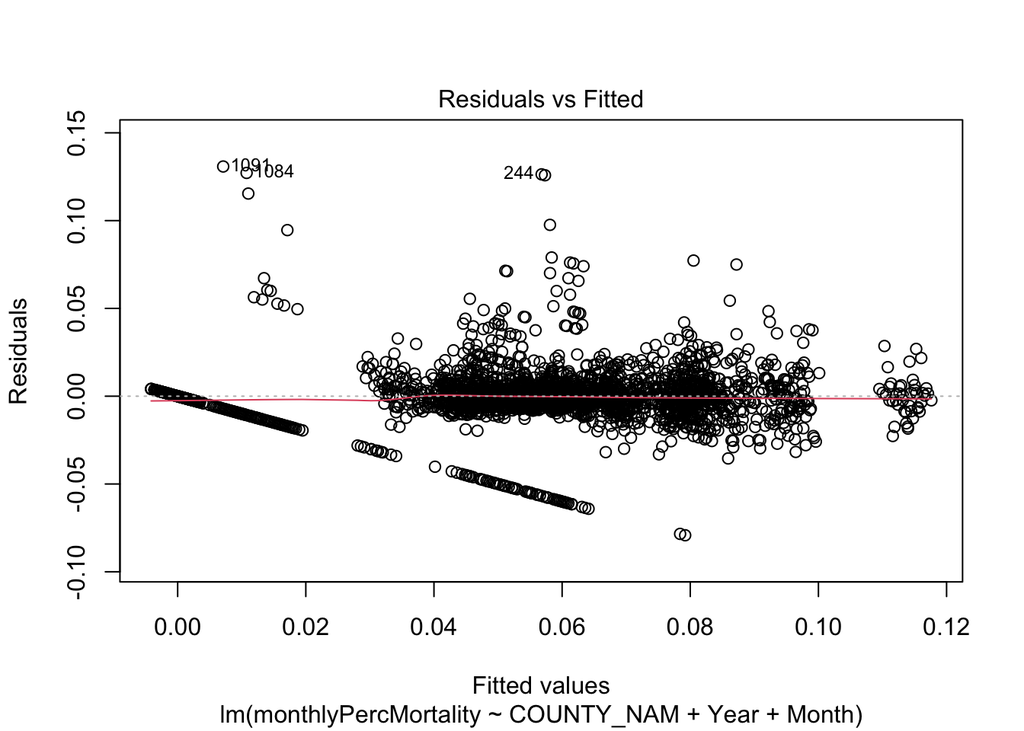

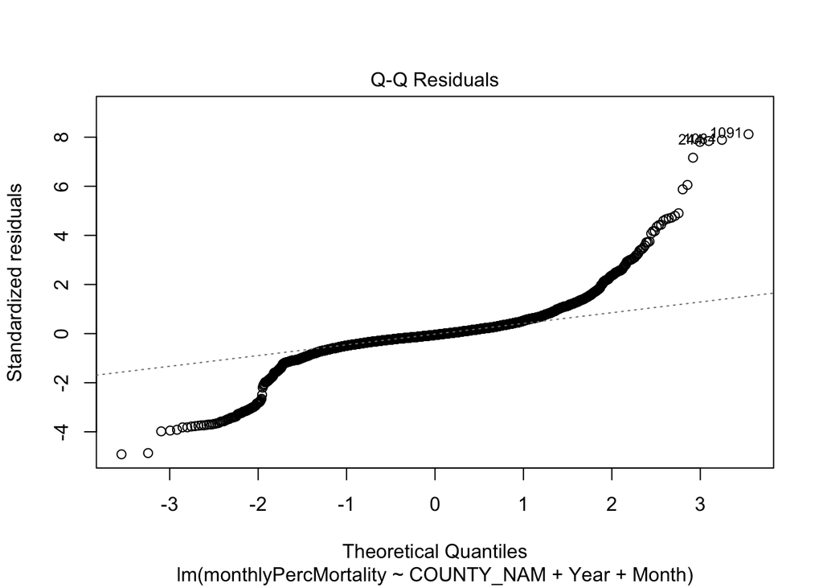

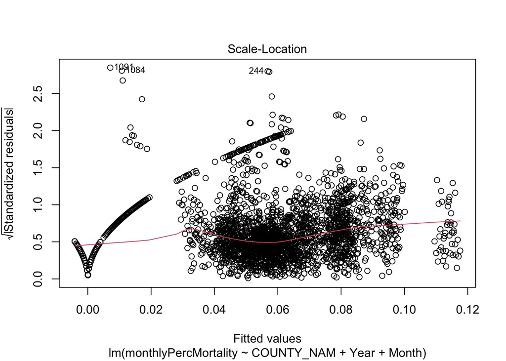

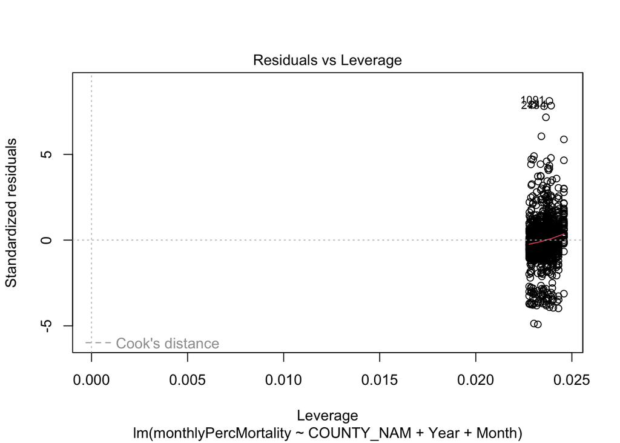

```r
plot(olsModel)
```

> We do not think this regression prediction is particularly robust. Looking at the diagnostic plots, several of the assumptions of OLS appear to be violated. The Q-Q plot shows that the residuals are not normally distributed, as there is substantial deviation from the reference line and several extreme observations in the tails. The Scale-Location plot also suggests that the variance of the residuals may not be constant across fitted values, indicating potential heteroscedasticity. In addition, the Residuals vs Leverage plot shows a few observations with relatively large residuals that may be influencing the model. Beyond the diagnostic plots, the model itself is fairly simple because it only uses county, year, and month to predict mortality. It does not account for seasonality, spatial effects, COVID-19 outbreaks, demographic differences, or other factors that could influence mortality. As a result, the predictions may provide a rough estimate of future mortality, but we would be cautious about treating them as highly accurate forecasts.

## 3.2 Spatial lag regression

Then you recall that class you took during your Master’s degree - what was it called again? Doesn’t matter! You remember that calculating **spatial weights** would allow you to do a type of spatial regression, such as spatial lag regression, because it deals with **spatial autocorrelation**. Right, that was the term!

### 3.2.1 Calculate spatial weights matrix

The first step in calculating a spatial weights matrix is to ensure geometry is retained in the shapefile, even if you plan to aggregate by month or by year for mapping. I actually had you covered earlier when you first calculated the monthly percent mortality, `monthlyPercMortality`, in the **mortality shapefile**, `mortality_sf2`. By ungrouping at the end of the calculation, I ensured that you lost no data or geometry! This is also exactly WHY you did not do any aggregation directly on these data or attach the subpar predictions to `mortality_sf2`.

**Warning**: Careless aggregation WILL rob you of spatial or other information, which will make spatial modeling impossible. This is because, in order to run spatial models, the spatial object *must* retain geometry.

Now that you know you have retained all of your spatial information in `mortality_sf2`, you can create the spatial weights matrix similarly to how you did it in Demo 2 using `spdep`.

1. Create neighbor list using Queen contiguity. *This could take a minute to run, be patient.*

*This identifies which counties touch each other (using `poly2nb()`). Note, however, that you are only looking at the* **unique pairs** *of county names and geometries, however, for this step.*

```r
mortality_nb <- poly2nb(mortality_sf2 %>%
                          ## Isolate the unique county name-geometry pairs
                          select(COUNTY_NAM, geometry) %>% unique() %>%
                          ## Arrange the county names alphabetically (helps
                          ## ensure no downstream issues)
                          arrange(COUNTY_NAM) %>%
                          ## Turns the county name into a factor (helps ensure
                          ## no downstream issues)
                          mutate(COUNTY_NAM = as_factor(COUNTY_NAM)))


## Make sure the size matches the number of counties:
length(mortality_nb)
```

```
## [1] 58
```

#### Question 17A [0.5 points]

Why am I calculating the neighbors on just the **distinct counties** in the mortality shapefile when I just finished saying you don’t want to lose any of your spatial data for the model?

**Hint 1**: What are the dimensions of `mortality_sf2` and is it a multiple of 58?

**Hint 2**: What happens if I calculate spatial weights on redundant data? Does it cost me computationally?

```r
mortality_sw <- nb2listw(mortality_nb, style = "W", zero.policy = TRUE)
```

### 3.2.2 Join spatial weights to the mortality shapefile so that every datapoint has its spatial weight.

You want to calculate, for each county in each year and month, the average percent mortality of its neighboring counties (i.e., the spatial lag). This helps you model whether mortality in one county is influenced by nearby counties. Recall from lecture and Demo 2 that a **spatial lag** is the weighted average of a variable (here, mortality) in neighboring counties. For example, if Los Angeles county is surrounded by five counties, the spatial lag for L.A. county is the average mortality rate across those five neighbors, adjusted by the spatial weights.

To accomplish this, what you need to do is loop over the time components (year and then month), and compute spatial lag for within each of the four years. you will use `purrr` to do this; it’s more computationally efficient than writing a more simple `for()` loop. As it iterates over the dataset, by year, it will use `spdep::lag.listw()` to calculate the spatial lag for each time point. The result is a new column in `mortality_sf2` that contains the average monthly mortality of any given county’s neighbors for every county-month-year combination. **Don’t forget!** You must center (not scale) the monthly percent mortality before computing the spatial weights.

```r
## Make a centered transformation of monthly percent mortality
mortality_sf2$monthlyPercMortalityCentered <- scale(mortality_sf2$monthlyPercMortality,
                                    center = TRUE, scale = FALSE)

## Initialize an empty vector to store spatial lag values
mortality_sf2$lagged_monthlyPercMortality <- NA_real_

## Calculate spatial weights for every time point
mortality_sf2 <- mortality_sf2 %>%
  arrange(COUNTY_NAM, Year, Month) %>%  ## Ensures it is in same order as weights
  ## Handles each time slice separately
  group_by(Year, Month) %>%
  mutate(
    lagged_monthlyPercMortality = {
      ## Slice to get the current group's data (i.e., one month-year combo)
      ## and then sort within group to match spatial weights
      monYr <- arrange(cur_data(), COUNTY_NAM)$monthlyPercMortalityCentered
      ## Compute the spatial lag using the spatial weights in mortality_sw
      lag.listw(mortality_sw, monYr)
    }
  ) %>%
  ungroup()
```

### 3.2.3 Run spatial lag regression using the lagged monthly mortality as a covariate

In Demo 2, you used the `spatialreg` package’s `lagsarlm()` function to perform a spatial lag regression. However, because you needed to compute the spatial lag within each year-month combo for each county, you have to perform your spatial lag regression a little differently using just the `lm()` function and explicitly using the spatially lagged monthly percent mortality ourselves.

#### Question 17B [0.25 points]

Run a **spatial lag regression (SAR)** model using the spatial lag you just calculated. Save the model as an object called `sarModel`. I have gotten it started for you so you use the spatial lag correctly, but you need to fill in the blanks, run the analysis, and assess the results.

**Hint 1**: Your target (dependent variable) is unchanged from OLS regression.

**Hint 2**: Make sure to include both time elements as covariates!

```r
sarModel <- lm(monthlyPercMortality ~ COUNTY_NAM + Year + Month + lagged_monthlyPercMortality,
               data = mortality_sf2)

summary(sarModel)
```

```
##
## Call:
## lm(formula = monthlyPercMortality ~ COUNTY_NAM + Year + Month +
##     lagged_monthlyPercMortality, data = mortality_sf2)
##
## Residuals:
##       Min        1Q    Median        3Q       Max
## -0.078164 -0.004791 -0.000635  0.004438  0.133671
##
## Coefficients:
##                                Estimate  Std. Error t value
## (Intercept)                 -1.14889429  0.61485161  -1.869
## COUNTY_NAMAlpine            -0.05166274  0.00344226 -15.008
## COUNTY_NAMAmador             0.03005154  0.00345834   8.690
## COUNTY_NAMButte              0.04409364  0.00344145  12.813
## COUNTY_NAMCalaveras          0.01414368  0.00344562   4.105
## COUNTY_NAMColusa             0.00802487  0.00344426   2.330
## COUNTY_NAMContra Costa       0.00321785  0.00344900   0.933
## COUNTY_NAMDel Norte          0.02673975  0.00360620   7.415
## COUNTY_NAMEl Dorado          0.00709148  0.00344204   2.060
## COUNTY_NAMFresno             0.01596718  0.00348766   4.578
## COUNTY_NAMGlenn             -0.01211036  0.00350468  -3.455
## COUNTY_NAMHumboldt           0.02504293  0.00345492   7.248
## COUNTY_NAMImperial          -0.00716570  0.00344148  -2.082
## COUNTY_NAMInyo               0.03350960  0.00349654   9.584
## COUNTY_NAMKern               0.00366564  0.00344359   1.064
## COUNTY_NAMKings             -0.00540637  0.00344145  -1.571
## COUNTY_NAMLake               0.02638432  0.00344432   7.660
## COUNTY_NAMLassen            -0.01448909  0.00349598  -4.144
## COUNTY_NAMLos Angeles        0.00475859  0.00344145   1.383
## COUNTY_NAMMadera            -0.00072696  0.00345449  -0.210
## COUNTY_NAMMarin              0.01187516  0.00344609   3.446
## COUNTY_NAMMariposa          -0.00075477  0.00345627  -0.218
## COUNTY_NAMMendocino          0.01876585  0.00344174   5.452
## COUNTY_NAMMerced            -0.01053147  0.00344266  -3.059
## COUNTY_NAMModoc             -0.04807154  0.00354426 -13.563
## COUNTY_NAMMono              -0.05099032  0.00344150 -14.816
## COUNTY_NAMMonterey          -0.00060520  0.00344689  -0.176
## COUNTY_NAMNapa               0.02503297  0.00345135   7.253
## COUNTY_NAMNevada             0.03067110  0.00344333   8.907
```

[output cut: 85 more lines]

```
## COUNTY_NAMTrinity           < 0.0000000000000002 ***
## COUNTY_NAMTulare                        0.899890
## COUNTY_NAMTuolumne          < 0.0000000000000002 ***
## COUNTY_NAMVentura                       0.169180
## COUNTY_NAMYolo                          0.025317 *
## COUNTY_NAMYuba              < 0.0000000000000002 ***
## Year                                    0.050592 .
## Month                        0.00008735910845719 ***
## lagged_monthlyPercMortality  0.00000000000089342 ***
## ---
## Signif. codes:  0 '***' 0.001 '**' 0.01 '*' 0.05 '.' 0.1 ' ' 1
##
## Residual standard error: 0.01614 on 2491 degrees of freedom
## Multiple R-squared:  0.6748, Adjusted R-squared:  0.6669
## F-statistic: 86.14 on 60 and 2491 DF,  p-value: < 0.00000000000000022
```

Now, let’s compare `sarModel` to `olsModel` and see which model better explains monthly percent mortality in California (uncomment to run).

```r
anova(sarModel, olsModel)
```

```
## Analysis of Variance Table
##
## Model 1: monthlyPercMortality ~ COUNTY_NAM + Year + Month + lagged_monthlyPercMortality
## Model 2: monthlyPercMortality ~ COUNTY_NAM + Year + Month
##   Res.Df     RSS Df Sum of Sq      F             Pr(>F)
## 1   2491 0.64905
## 2   2492 0.66250 -1 -0.013446 51.603 0.0000000000008934 ***
## ---
## Signif. codes:  0 '***' 0.001 '**' 0.01 '*' 0.05 '.' 0.1 ' ' 1
```

#### Question 17C [0.25 points]

Which model, the spatial lag regression (`sarModel`) or the ordinary least squares regression (`olsModel`), is a better fit to the data? Why?

> The spatial lag regression (SAR) model is a better fit to the data than the OLS model. The ANOVA comparison shows that adding the spatial lag variable significantly improves model performance (F = 51.603, p < 0.001). In addition, the spatial lag coefficient is highly significant (p < 0.001), suggesting that mortality rates in neighboring counties are associated with mortality rates within a county. Therefore, accounting for spatial dependence improves the model’s ability to explain monthly percent mortality compared to the standard OLS regression.

#### Question 17D [0.5 points]

Using the model you chose as the better model, `sarModel` to `olsModel`, interpret the results of that model. **HINT**: Remember that `summary()` helps you access the results from the model!

Make sure to interpret both the coefficients and their significance as well as the $R^2$!

```r
## View the results of the better-fitting SAR model
summary(sarModel)
```

```
##
## Call:
## lm(formula = monthlyPercMortality ~ COUNTY_NAM + Year + Month +
##     lagged_monthlyPercMortality, data = mortality_sf2)
##
## Residuals:
##       Min        1Q    Median        3Q       Max
## -0.078164 -0.004791 -0.000635  0.004438  0.133671
##
## Coefficients:
##                                Estimate  Std. Error t value
## (Intercept)                 -1.14889429  0.61485161  -1.869
## COUNTY_NAMAlpine            -0.05166274  0.00344226 -15.008
## COUNTY_NAMAmador             0.03005154  0.00345834   8.690
## COUNTY_NAMButte              0.04409364  0.00344145  12.813
## COUNTY_NAMCalaveras          0.01414368  0.00344562   4.105
## COUNTY_NAMColusa             0.00802487  0.00344426   2.330
## COUNTY_NAMContra Costa       0.00321785  0.00344900   0.933
## COUNTY_NAMDel Norte          0.02673975  0.00360620   7.415
## COUNTY_NAMEl Dorado          0.00709148  0.00344204   2.060
## COUNTY_NAMFresno             0.01596718  0.00348766   4.578
## COUNTY_NAMGlenn             -0.01211036  0.00350468  -3.455
## COUNTY_NAMHumboldt           0.02504293  0.00345492   7.248
## COUNTY_NAMImperial          -0.00716570  0.00344148  -2.082
## COUNTY_NAMInyo               0.03350960  0.00349654   9.584
## COUNTY_NAMKern               0.00366564  0.00344359   1.064
## COUNTY_NAMKings             -0.00540637  0.00344145  -1.571
## COUNTY_NAMLake               0.02638432  0.00344432   7.660
## COUNTY_NAMLassen            -0.01448909  0.00349598  -4.144
## COUNTY_NAMLos Angeles        0.00475859  0.00344145   1.383
## COUNTY_NAMMadera            -0.00072696  0.00345449  -0.210
## COUNTY_NAMMarin              0.01187516  0.00344609   3.446
## COUNTY_NAMMariposa          -0.00075477  0.00345627  -0.218
## COUNTY_NAMMendocino          0.01876585  0.00344174   5.452
## COUNTY_NAMMerced            -0.01053147  0.00344266  -3.059
## COUNTY_NAMModoc             -0.04807154  0.00354426 -13.563
## COUNTY_NAMMono              -0.05099032  0.00344150 -14.816
## COUNTY_NAMMonterey          -0.00060520  0.00344689  -0.176
## COUNTY_NAMNapa               0.02503297  0.00345135   7.253
## COUNTY_NAMNevada             0.03067110  0.00344333   8.907
```

[output cut: 85 more lines]

```
## COUNTY_NAMTrinity           < 0.0000000000000002 ***
## COUNTY_NAMTulare                        0.899890
## COUNTY_NAMTuolumne          < 0.0000000000000002 ***
## COUNTY_NAMVentura                       0.169180
## COUNTY_NAMYolo                          0.025317 *
## COUNTY_NAMYuba              < 0.0000000000000002 ***
## Year                                    0.050592 .
## Month                        0.00008735910845719 ***
## lagged_monthlyPercMortality  0.00000000000089342 ***
## ---
## Signif. codes:  0 '***' 0.001 '**' 0.01 '*' 0.05 '.' 0.1 ' ' 1
##
## Residual standard error: 0.01614 on 2491 degrees of freedom
## Multiple R-squared:  0.6748, Adjusted R-squared:  0.6669
## F-statistic: 86.14 on 60 and 2491 DF,  p-value: < 0.00000000000000022
```

```r
## Pull model fit statistics
summary(sarModel)$r.squared
```

```
## [1] 0.6747806
```

```r
summary(sarModel)$adj.r.squared
```

```
## [1] 0.6669471
```

> The SAR model explains approximately 67.5% of the variation in monthly percent mortality across California counties (R² = 0.675, Adjusted R² = 0.667), indicating that the model provides a reasonably strong fit to the data. One of the most important results is the spatial lag coefficient, which is positive and statistically significant (β = 0.292, p < 0.001). This suggests that counties tend to have mortality rates that are similar to those of their neighboring counties. In other words, mortality appears to exhibit spatial autocorrelation, meaning that nearby counties are not completely independent of one another. The Month variable is also statistically significant (β = -0.000386, p < 0.001), indicating that mortality changes over time throughout the year. The Year coefficient is positive and marginally significant (p = 0.051), suggesting a slight upward trend in mortality over the study period, although the evidence is relatively weak. Several county coefficients are statistically significant as well, indicating that mortality rates differ across counties even after accounting for time and neighboring county effects. For example, Shasta County has a large positive coefficient (β = 0.0666, p < 0.001), suggesting higher mortality relative to the reference county, while counties such as Alpine and Modoc have significantly lower mortality rates. Overall, these results suggest that both geographic location and neighboring county mortality patterns play an important role in explaining variation in monthly mortality across California counties.

#### Question 17E [0.25 points]

Can you trust the results of the model? Why or why not?

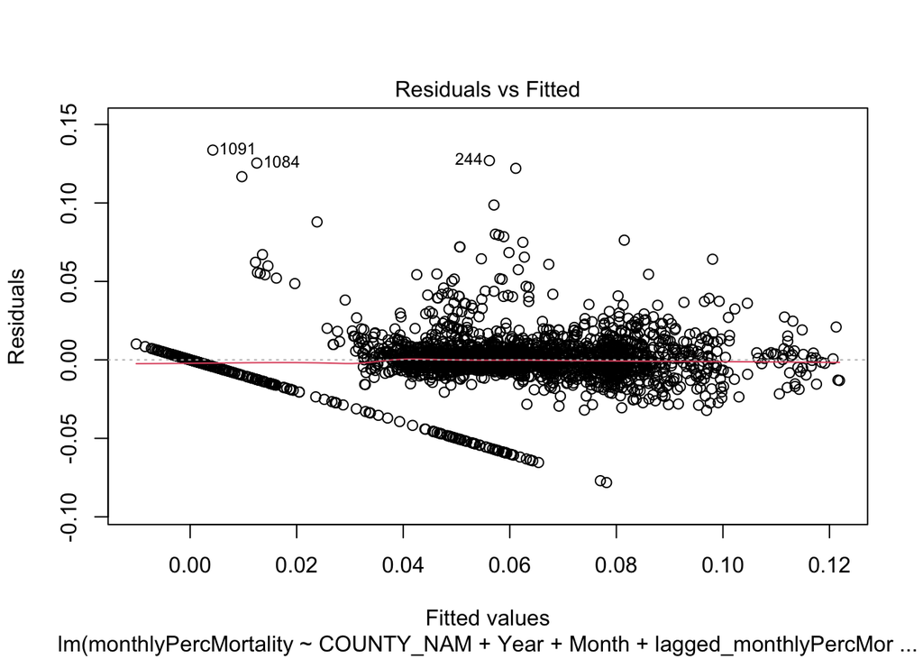

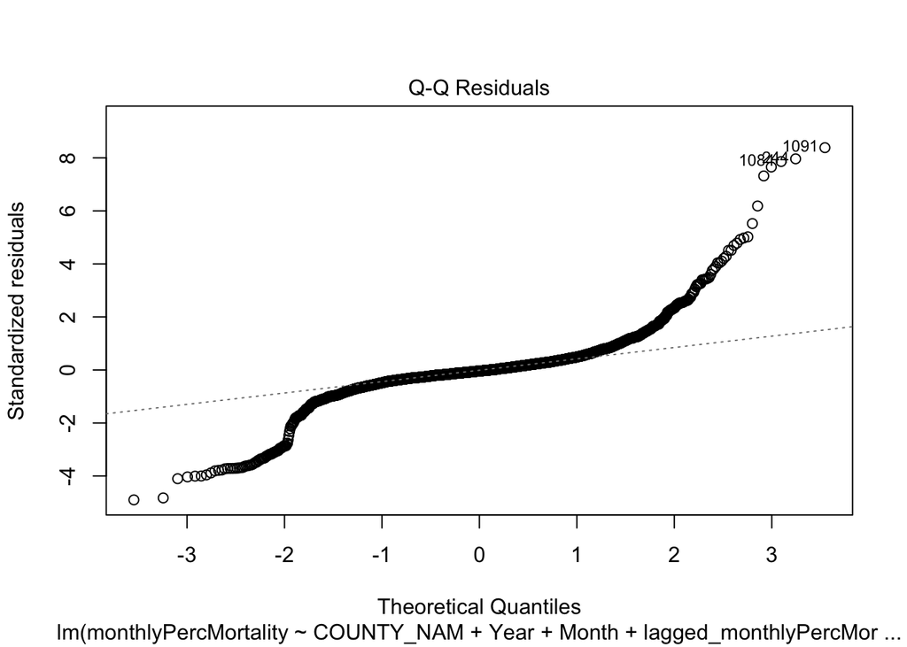

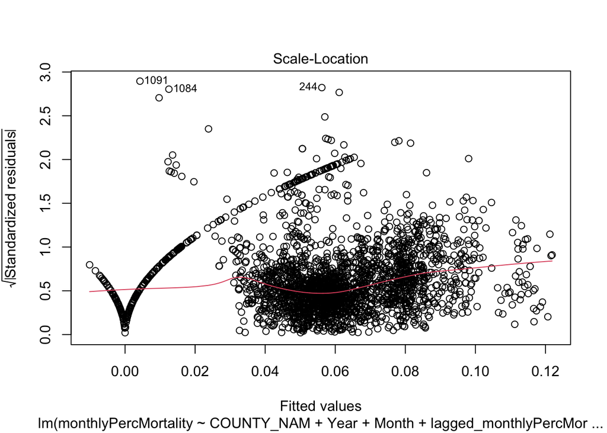

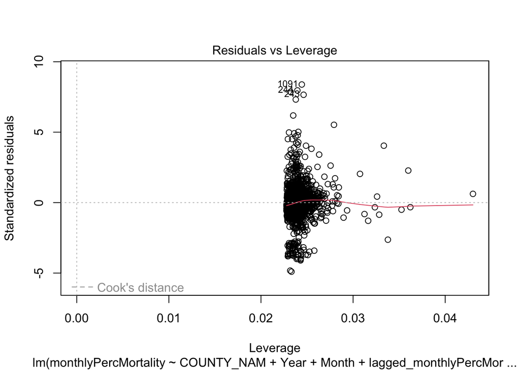

```r
plot(sarModel)
```

> Based on the diagnostic plots, we would be somewhat cautious about fully trusting the results of the SAR model. While the model is clearly an improvement over the OLS model and explains about 67.5% of the variation in monthly mortality, several of the regression assumptions do not appear to be fully met. Looking at the Q-Q plot, the residuals deviate noticeably from the reference line, especially in the tails, which suggests that the residuals are not normally distributed. We can also see a few potential outliers and influential observations in the Residuals vs Leverage plot. In addition, the Scale-Location plot shows some variation in the spread of the residuals, suggesting that the variance may not be completely constant across fitted values. However, despite these issues, the SAR model still appears to perform better than the OLS model because the spatial lag term is highly significant and the model explains a substantial amount of the variation in mortality. Overall, we would consider the SAR model useful for understanding patterns in the data, but we would interpret the results with caution because some of the model assumptions are not fully satisfied.

# 4 Improve Predictions with Machine Learning

You are growing increasingly concerned that you will not be able to provide robust predictions to your stakeholder, and you’re feeling nervous - it is a new job, after all! So, you think about other ways to try to **improve the prediction**. Although you technically can’t see into the future, right now, you and I can - which is exactly what you are going to do! Unlike the random splits you have done before, you are actually going to perform what is called a **time-aware split**, where you use January 2017 to December 2019 as your training data and January to August 2020 as your testing data. This approach accounts for *temporal structure* in the data, as well as spatial structure in the data by using the lagged mortality you computed above as a spatial proxy.

*Perform a time-aware train-test split*

```r
## Make the training data
mortalityTrain <- mortality_sf2 %>%
  ## Drop the geometry to make processing downstream faster
  st_drop_geometry() %>%
  ## Filter for just the year-month combos you want
  filter(Year != 2020) %>%
  ## Drop the previously centered monthly percent mortality from when you made
  ## the spatial weights matrix
  select(-monthlyPercMortalityCentered)

## Make the testing data
mortalityTest <- mortality_sf2 %>%
  ## Drop the geometry to make processing downstream faster
  st_drop_geometry() %>%
  ## Filter for just the year-month combos you want
  filter(Year == 2020) %>%
  ## Drop the previously centered monthly percent mortality from when you made
  ## the spatial weights matrix
  select(-monthlyPercMortalityCentered)
```

#### Question 18A [0.5 points]

What percent of the data are in the training set and what percent in the testing set? You should use code to figure this out! How does it compare to the canonical 80-20 split?

```r
nrow(mortalityTrain)
```

```
## [1] 2088
```

```r
nrow(mortalityTest)
```

```
## [1] 464
```

```r
nrow(mortalityTrain) / (nrow(mortalityTrain) + nrow(mortalityTest)) * 100
```

```
## [1] 81.81818
```

```r
nrow(mortalityTest) / (nrow(mortalityTrain) + nrow(mortalityTest)) * 100
```

```
## [1] 18.18182
```

> The training set contains 2,088 observations, while the testing set contains 464 observations. This means that approximately 81.8% of the data are in the training set and 18.2% are in the testing set. This is very close to the canonical 80-20 train-test split commonly used in machine learning. The main difference is that our split is time-aware rather than random, since all observations from 2017-2019 were used for training and all observations from 2020 were used for testing. This approach is more appropriate for forecasting because it prevents future information from leaking into the training data.

#### Question 18B [0.5 points]

What caveats or limitations can you think of by using none of the 2020 data in the training set?

> One limitation of excluding all 2020 data from the training set is that the model never gets to learn the unique conditions that occurred during 2020, particularly the effects of COVID-19. As a result, the model is being trained on mortality patterns from relatively normal years and then asked to make predictions during a period that was very different from anything it had previously seen. Another limitation is that we only have three years of training data, which may not be enough to fully capture longer-term trends or unusual fluctuations in mortality. At the same time, mortality patterns can change over time due to factors such as disease outbreaks, changes in healthcare access, or demographic shifts. Because of this, the model may struggle to generalize to conditions that were not present in the training data. However, using a time-aware split is still appropriate because it reflects how forecasting would work in the real world. We would not have access to future data when making predictions, so this approach helps prevent data leakage while providing a more realistic assessment of model performance.

## 4.1 Fitting an out-of-bag (OOB) random forest (RF) model

You decide to use random forest (RF) for this task because it handles non-linearity, which you know you have from your time plots above AND from the summaries of both your OLS and SAR regressions. You also choose to use RF because it can be more robust to outliers and still give some idea of importance for interpretability for your stakeholders. Your basic workflow will be to:

1. Center and scale the predictors
2. Fit the model with OOB error
3. Fit the model with 10-fold cross-validation
4. Compare the RMSE of the two models
5. Show the variable importance of the final model

You decide to leverage the `caret` package in R again for much of your model fitting and tuning needs. If you want to know more about what `caret` does and doesn’t do, this [chapter](https://daviddalpiaz.github.io/r4sl/the-caret-package.html) can help.

#### Question 19A [0.5 points]

What does it mean to “fit a model with out-of-bag (OOB) error”? Why do we do it? What can it tell you here?

> Fitting a model with out-of-bag (OOB) error means that each tree in the random forest is evaluated using observations that were not used to build that particular tree. Because random forests are built using bootstrap samples, some observations are left out during the training of each tree. These unused observations are called out-of-bag observations and can be used to estimate prediction error. We use OOB error because it provides an internal measure of model performance without requiring a separate validation dataset. In this project, the OOB error gives us an idea of how well the random forest may generalize to unseen mortality data and helps us evaluate the model before comparing it to other approaches.

Even though you have no encoding, you know that you need to center and scale your data before running the random forest! So, you decide to leverage the `preProcess()` function in the `caret` package to help you center and scale the predictors. You perform the preprocessing explicitly here, storing the pre-processed training *instructions* in `preProcInstructions`. Then, you can apply the pre-processing to the training data, `mortalityTrain`, using the `predict()` function. Note that this is a different step than when you are predicting from a model for performance evaluation!

```r
## First, make a new object, preProcInstructions, that stores the
## pre-processing instructions from mortalityTrain:
preProcInstructions <- preProcess(mortalityTrain,
                                    method = c("center", "scale"))

## Now apply the pre-processing instructions using predict()
mortalityTrain <- predict(preProcInstructions,
                                      newdata = mortalityTrain)
```

Then, you fit the OOB RF model after using the `trainControl()` function to tell it to fit the training model with OOB error.

*Fit an OOB random forest (RF) model*

```r
## Define training control for OOB
ctrlOOB <- trainControl(method = "oob")

## Define the tuning grid
tuneGrid <- expand.grid(mtry = 1:3)  ## Coerce it to use mtry 1 through 3

## Run the OOB random forest, including preprocessing instructions
rfOOB <- train(
  ## Define the model - everything but COUNTY_NAM
  monthlyPercMortality ~ Year + Month + lagged_monthlyPercMortality,
  ## Set the data
  data = mortalityTrain,
  ## Indicate that it is a random forest
  method = "rf",
  ## Indicate the training control method to use, defined above
  trControl = ctrlOOB,
  ## Indicate that you want to extract importance at the end
  importance = TRUE,
  ## Indicate the tuning grid, defined explicitly above
  tuneGrid = tuneGrid
)
```

Note that here you coerce it to use an `mtry` hyperparameter grid search of 1 through 3. This is just because you have a really non-complex dataset (only 3 predictors!) and you want to force it to run *as if* it had a little more complexity. Why? Just to make sure it searches long enough!

#### Question 19B [0.5 points]

What is `mtry` and what is it doing in the context of a random forest? What is the default `mtry` for a random forest regression? Why am I choosing to override it here, do you think?

> The mtry parameter controls how many predictor variables are randomly considered at each split in a decision tree within the random forest. This randomness helps reduce correlation between trees and improves the overall performance of the forest. For regression problems, the default value of mtry is typically one-third of the number of predictors. Since we only have three predictors in this model (Year, Month, and lagged monthly mortality), the default mtry would be 1. The instructor is overriding the default by testing values of 1 through 3 so that the model can perform a small hyperparameter search and determine which value produces the best performance. Because the dataset has very few predictors, forcing the model to evaluate multiple mtry values helps ensure that the random forest explores different levels of complexity rather than automatically using the default value.

*Look at the results ($RMSE$ and $R^2$) of the OOB random forest*

```r
rfOOB$results %>%
  kable(
    format = "html",
    caption = "Table 3. Results of the OOB random forest on California Mortality (All Causes).") %>%
    kable_styling(bootstrap_options = c("hover"))
```

Table 3. Results of the OOB random forest on California Mortality (All Causes).

| RMSE | Rsquared | mtry |
| --- | --- | --- |
| 0.9878845 | 0.0236167 | 1 |
| 1.0418551 | -0.0859821 | 2 |
| 1.0672538 | -0.1395764 | 3 |

Recall from the Elastic Net you fitted a couple weeks ago on the hospital readmissions data that you optimized a hyperparameter, $\lambda$, to get the best-tuned model. It is the same idea here with `mtry`. Remember, optimized results will be the **lowest error** as measured by Root Mean-Squared Error ($RMSE$) and the highest percent of the variance in the target explained, $R^2$. In other words, you want a model that uses as much information as it can, which results in lower error, and betters your chances that it will return a good prediction!

#### Question 19C [0.5 points]

Which value of `mtry` gave the best results? (**Hint**: Can $R^2$ values be negative?!?). Are you able to compare the $RMSE$ of this model to the one you fitted in Question 16C? Why or why not? (**Hint**: Does your pre-processing step apply to the target too? You may have to do a little research!)

## 4.2 Fitting a 10-fold cross-validated random forest (RF) model

You now feel decide to move forward with the 10-fold cross-validation. Remember that this is to **help control for overfitting**, which you can identify by looking at the error ($RMSE$) and fit ($R^2$) in each of the folds.

*Define the training control method as 10-fold cross-validation (CV) and run the model*

```r
## Define training control for 10-fold cross-validation
ctrlCV <- trainControl(method = "cv", number = 10)

## Run the 10-fold CV random forest, including preprocessing instructions
rfCV <- train(
  ## Define the model
  monthlyPercMortality ~ Year + Month + lagged_monthlyPercMortality,
  ## Set the data
  data = mortalityTrain,
  ## Indicate that it is a random forest
  method = "rf",
  ## Indicate the training control method to use, defined above
  trControl = ctrlCV,
  ## Indicate that you want to extract importance at the end
  importance = TRUE,
  ## Indicate the tuning grid, defined explicitly earlier
  tuneGrid = tuneGrid
)
```

```r
rfCV$results %>%
  kable(
    format = "html",
    caption = "Table 4. Results of the 10-fold CV random forest on California Mortality (All Causes).") %>%
    kable_styling(bootstrap_options = c("hover"))
```

Table 4. Results of the 10-fold CV random forest on California Mortality (All Causes).

| mtry | RMSE | Rsquared | MAE | RMSESD | RsquaredSD | MAESD |
| --- | --- | --- | --- | --- | --- | --- |
| 1 | 0.9897826 | 0.0296301 | 0.7054996 | 0.0545654 | 0.0304994 | 0.0400658 |
| 2 | 1.0435425 | 0.0183467 | 0.7661781 | 0.0663570 | 0.0248857 | 0.0435530 |
| 3 | 1.0628948 | 0.0195421 | 0.7817532 | 0.0712987 | 0.0281687 | 0.0471315 |

#### Question 19D [0.5 points]

What do you notice about the effects of cross-validation on your model? (**Hint**: Do you see any negative $R^2$ values this time?) Which value of `mtry` gave the best results? How does the $RMSE$ of that model compare to the one you chose as the optimal OOB model?

## 4.3 Test the training model with the 2020 data

### 4.3.1 Preprocess your test data with the same centering/scaling

Since you used `caret`’s `preProcess()` during model training, then you also have to apply the same transformation to your testing data for predictions!

Notice that you will *first* store the pre-processed values for the training set in its own object, `preProcInstructions`, and then you apply the same pre-processing on the training set using the `predict()` function. This is **separate** from the predictions you will make on the testing set using the model!

```r
## Apply the same preprocessing as training using predict(),
## using the test data
mortalityTest <- predict(preProcInstructions, newdata = mortalityTest)
```

### 4.3.2 Predict using the best RF model

An advantage of using `caret` is that it will automatically identify your best model for us, which you can access by simply using the model object `rfCV` with `predict()`. **Make sure you think about why you are using `rfCV` and not `rfOOB` here!**

```r
## Predict on pre-processed test data using the best trained RF model
rfPredictions <- predict(rfCV, newdata = mortalityTest)
```

### 4.3.3 Evaluate performance with $RMSE$ and $MAE$

`caret` also has built-in functions to calculate key performance metrics, like $RMSE$ and $MAE$ for regression models or a confusion matrix with accuracy for classification models. You can read more about them in this [chapter](https://topepo.github.io/caret/measuring-performance.html).

```r
### Compute RMSE (Root Mean Squared Error)
rfRMSE <- RMSE(pred = rfPredictions, obs = mortalityTest$monthlyPercMortality)

## Compute MAE (Mean Absolute Error) as well, optionally
rfMAE <- MAE(pred = rfPredictions, obs = mortalityTest$monthlyPercMortality)

## Print results
print(paste0("Random Forest Test RMSE:   ", round(rfRMSE, 4)))
```

```
## [1] "Random Forest Test RMSE:   0.9852"
```

```r
print(paste0("Random Forest Test MAE:    ", round(rfMAE, 4)))
```

```
## [1] "Random Forest Test MAE:    0.7173"
```

#### Question 19E [0.5 points]

Can you interpret the $RMSE$ and $MAE$ values? **Remember** all of the data were subject to pre-processing, both target and predictors!

**How did the training model perform?** Does it seem to be overfitting (training error >> testing error), underfitting (training error and testing error both high but roughly equal with a low $R^2$), or doing okay?

### 4.3.4 Plot Actual vs. Predicted Values

Unimpressed with the results so far, you decide to plot the actual vs. predicted values because that can tell you whether your training model is likely leading to an **under prediction** or an **over prediction** relative to the true values of mortality. Using the `ggExtra` package, you add histograms to the margins of the scatterplot as well to help you interpret correctly.

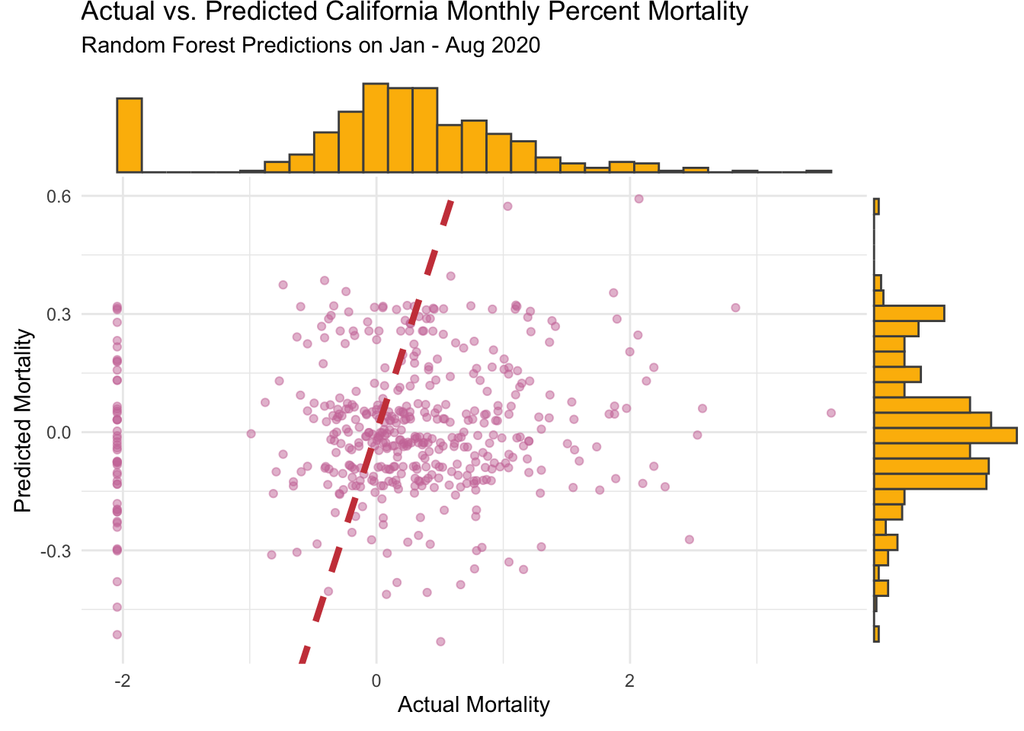

```r
## Make a scatterplot of the actual vs. predicted values
p <- ggplot(mortalityTest, aes(x = monthlyPercMortality, y = rfPredictions)) +
  ## Scatteplot with geom_point
  geom_point(alpha = 0.5, color = skittles[4]) +
  ## Add a line to help see the general trend
  geom_abline(color = skittles[3], linetype = "dashed", size = 1.5) +
  theme_minimal() +
  labs(
    title = "Actual vs. Predicted California Monthly Percent Mortality",
    subtitle = "Random Forest Predictions on Jan - Aug 2020",
    x = "Actual Mortality",
    y = "Predicted Mortality"
  )
## Add marginal histograms with the ggExtra package
ggMarginal(p, type = "histogram", fill = skittles[2], color = "gray30")
```

#### Question 19F [0.5 points]

Interpret the scatterplot of the actual vs. predicted values. What is happening to the predicted values? (Use the histogram on the side to help you, that’s why they’re there!) Make sure to mention whether the training model is leading to an **under prediction** or an **over prediction** of mortality. What **real information** might that provide your stakeholders, even if the model is underperforming?

> Looking at the scatterplot, the predicted values appear to be compressed toward the center and do not capture the full range of the actual mortality values. The marginal histograms help show this more clearly. The distribution of the actual mortality values is much wider, while the predicted values are concentrated within a narrower range. This means the model is smoothing the predictions and pulling them toward the average. As a result, the model underpredict higher mortality values and overpredict lower mortality values. In other words, when mortality is unusually high, the model predicts values that are too low, and when mortality is unusually low, the model predicts values that are too high. Even though the model is underperforming, it still provides useful information to stakeholders. The results suggest that mortality rates across California counties are generally stable and clustered around a central value, with only a limited number of extreme observations. The model also highlights that unusual spikes or drops in mortality are difficult to predict using only Year, Month, and lagged mortality. This suggests that additional factors, such as demographic characteristics, socioeconomic conditions, healthcare access, or major public health events, may be needed to improve predictions.

## 4.4 Extract variable importance from the final model

You also decide to extract the variable importance from the final trained model to share with your stakeholders.

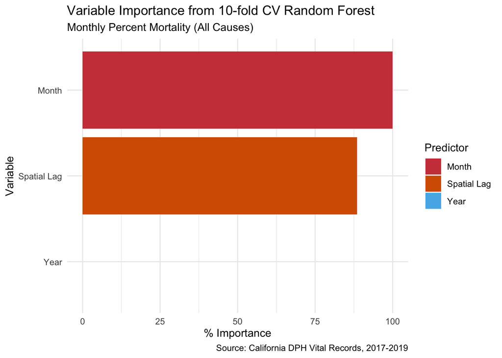

Table 5. Results of the 10-fold CV random forest on California Mortality (All Causes).

|  | Overall |
| --- | --- |
| Year | 0.00 |
| Month | 100.00 |
| lagged_monthlyPercMortality | 88.46 |

## 4.5 Comparing your predictions to the real deaths data

Now, let’s pretend that you’re skipping ahead a few months in time and you’re actually able to assess just how well your prediction could do in reality. While what you *could* do is fit a 10-fold, cross-validated random forest on all of the data and download the remaining months of 2020 and use all of 2020 as your test dataset, instead I’m just going to ask you to do a simple correlation to see how badly - or well - it did in reality.